# Final Report

Alvin Guo

```r
suppressWarnings({
  suppressMessages({
    library(tidyverse)
    library(maps)
    library(lubridate)
    library(shiny)
    library(slider)
    library(ranger)
    library(pROC)
    library(rsconnect)
  })
})
```

# Abstract

The goal of this report is **to predict whether a “notable” wildfire will occur in a grid by month panel of the contiguous United States**. We modified the dataset to be worked in space-time unit (grid by month). After analyzing spatial and temporal pattern, we implemented them alongside state monthly temperatures to create a baseline logistic regression model and two random forest models, one with temperature predictors and one without. After careful cross-validation that prevents data leakage, we then compared their predictive capabilities and **identified that random forest is a stronger predictive model by about 11.45% compared to logistic regression**. **Both random forest performed nearly the same**.

# 1) Data Preprocessing

## Datasets used

The full dataset [link](https://www.kaggle.com/datasets/rtatman/188-million-us-wildfires/data) contains 1.88 million entries of wildfires. The dataset of is of 795 MB in size. I use a smaller subset that contains 100,000 entries provided by Dr. Shizhe Chen for his Winter 2026 STA141A course at UC Davis. Detailed description of variables in the dataset is available on Kaggle.

**IMPORTANT NOTE**: For this prediction, we are focused mainly on the continental mainland of the United State. As such, states and territories such as Alaska, Hawaii, and Puerto Rico, which geographically and climate wise are substantially different from the mainland and will be filtered out of our dataset. I also safely filter out fires relating to Washington D.C from the data set as no fires from D.C are considered “notable” in this subset.

```r
#dataset with 100k wildfires
wildFire100k <- read_csv(file = "./Data/wildfires_sample_100k.csv", show_col_types = FALSE)
wildFire100k <- wildFire100k %>%
  filter(STATE != "AK", STATE != "HI", STATE != "PR", STATE != "DC")
head(wildFire100k)
```

```
## # A tibble: 6 × 39
##   OBJECTID FOD_ID FPA_ID  SOURCE_SYSTEM_TYPE SOURCE_SYSTEM NWCG_REPORTING_AGENCY
##      <dbl>  <dbl> <chr>   <chr>              <chr>         <chr>
## 1       16     16 FS-141… FED                FS-FIRESTAT   FS
## 2       68     68 FS-141… FED                FS-FIRESTAT   FS
## 3       73     74 FS-141… FED                FS-FIRESTAT   FS
## 4      111    112 FS-141… FED                FS-FIRESTAT   FS
## 5      191    194 FS-141… FED                FS-FIRESTAT   FS
## 6      228    231 FS-141… FED                FS-FIRESTAT   FS
## # ℹ 33 more variables: NWCG_REPORTING_UNIT_ID <chr>,
## #   NWCG_REPORTING_UNIT_NAME <chr>, SOURCE_REPORTING_UNIT <chr>,
## #   SOURCE_REPORTING_UNIT_NAME <chr>, LOCAL_FIRE_REPORT_ID <chr>,
## #   LOCAL_INCIDENT_ID <chr>, FIRE_CODE <chr>, FIRE_NAME <chr>,
## #   ICS_209_INCIDENT_NUMBER <chr>, ICS_209_NAME <chr>, MTBS_ID <chr>,
## #   MTBS_FIRE_NAME <chr>, COMPLEX_NAME <chr>, FIRE_YEAR <dbl>,
## #   DISCOVERY_DATE <dbl>, DISCOVERY_DOY <dbl>, DISCOVERY_TIME <chr>, …
```

I also used [link](https://www.kaggle.com/datasets/justinrwong/average-monthly-temperature-by-us-state) to contribute the monthly/annual temperature of the states (in Fahrenheit) to this project. Credit to Justin Wong.

What I modified:

- filtered to ONLY include years between 1992 and 2015
- removed all other columns outside of `month`, `year`, `state`, `average_temp`
- put all state names in column `state` into lowercase

```r
state_monthly_year_temp <- read_csv(file = "./Data/states_monthly_yearly_temp.csv", show_col_types = FALSE)
head(state_monthly_year_temp)
```

```
## # A tibble: 6 × 4
##   month  year state       average_temp
##   <chr> <dbl> <chr>              <dbl>
## 1 01     1992 alabama             47
## 2 01     1992 arizona             40.7
## 3 01     1992 arkansas            43
## 4 01     1992 california          43.6
## 5 01     1992 colorado            25.3
## 6 01     1992 connecticut         30.7
```

## Temporal Patterns and Threshold for “Notable” Fires

For our predictive purposes, I want to emphasize and use these specific columns: - `FIRE_YEAR` - `DISCOVERY_DOY` - `FIRE_SIZE` - `LATITUDE` - `LONGITUDE` - `STATE` So I will mainly focus on these columns.

We use `FIRE_YEAR` and `DISCOVERY_DOY` to create a new column `FIRE_DATE` that puts the date in which the fire started in the format Y-M-D. We can also then separate that to get the individual year and month of each fire in the `YEAR` and `MONTH` column.

For our predictive tasks, we are interested in identifying and predicting “**notable**” fires that can cause major damage. In order to reflect this, we will filter the dataset to include only fires with a final burned size of 300 acres (`FIRE_SIZE` >= 300) which is generally a guideline for reportable large grassland fires according to the US Environmental Protection Agency. [Source](https://www.epa.gov/sites/default/files/2021-04/documents/wildfires_td.pdf)

```r
#Filtered for notable fires
notableFires <- wildFire100k %>%
  select(FIRE_YEAR, DISCOVERY_DOY, FIRE_SIZE, LATITUDE, LONGITUDE, STATE) %>%
  mutate(STATE = as.factor(STATE)) %>%
  filter(FIRE_SIZE >= 300)
```

```r
#Mutate column for FireDate and get Year and Month individually
notableFiresTime <- notableFires %>%
    mutate(FIRE_DATE = as.Date(paste(FIRE_YEAR, DISCOVERY_DOY, sep = "-"), format = "%Y-%j"),
          YEAR = year(FIRE_DATE),
          MONTH = month(FIRE_DATE))
```

## Creating a Grid for Spatial Pattern

We create a 1x1 latitude/longitude grid cells that we can **use to identify where a wildfire occurred**. We will also predict if a notable wild fire will occur in these cells.

```r
#GRID and for each lat and long
notableFiresTime <- notableFiresTime %>%
  mutate(
    lat_bin = floor(LATITUDE),
    lon_bin = floor(LONGITUDE),
    ym = YEAR * 100 + MONTH   # e.g., 201507
  )
```

```r
# Fire indicator at (grid, month): did any notable fire occur?
suppressMessages({
  grid_month_fire <- notableFiresTime %>%
  group_by(lat_bin, lon_bin, ym) %>%
  summarize(n_fires = n(),
            fire_this_month = as.numeric(n_fires > 0))

})


head(grid_month_fire)
```

```
## # A tibble: 6 × 5
## # Groups:   lat_bin, lon_bin [3]
##   lat_bin lon_bin     ym n_fires fire_this_month
##     <dbl>   <dbl>  <dbl>   <int>           <dbl>
## 1      25     -98 199607       1               1
## 2      25     -82 200012       1               1
## 3      25     -81 199807       1               1
## 4      25     -81 200106       1               1
## 5      25     -81 200305       1               1
## 6      25     -81 200403       1               1
```

```r
# ---- Build panel (all grid cells that appear at least once) ----
all_grids <- grid_month_fire %>% distinct(lat_bin, lon_bin)

# Generate a safe monthly sequence using actual dates
start_date <- ymd(paste0(min(grid_month_fire$ym) %/% 100, "-", min(grid_month_fire$ym) %% 100, "-01"))
end_date   <- ymd(paste0(max(grid_month_fire$ym) %/% 100, "-", max(grid_month_fire$ym) %% 100, "-01"))

all_months <- tibble(date = seq.Date(start_date, end_date, by = "month")) %>%
  mutate(year = year(date), month = month(date), ym = year * 100 + month) %>%
  select(ym, year, month)

# Full panel = grid × month

panel <- crossing(all_grids, all_months) %>%
  left_join(grid_month_fire, by = c('lat_bin', 'lon_bin', 'ym') )

#Any NAs are to be replaced with 0 as that month, year, location did not have a notable wildfire
panel$n_fires[is.na(panel$n_fires)] <- 0
panel$fire_this_month[is.na(panel$fire_this_month)] <- 0
```

## Predictability Column

We add a binary column `y_next` that returns 1 if the same lat/long cell next month has at least one notable wildfire. (0 is not)

```r
panel <- panel %>%
  arrange(lat_bin, lon_bin, ym) %>%
  group_by(lat_bin, lon_bin) %>%
  mutate(
    y_next = lead(fire_this_month, n = 1L)
  ) %>%
  ungroup() %>%
  filter(!is.na(y_next))

table(panel$y_next)
```

```
##
##      0      1
## 126627   1215
```

## Baseline Predictors

### `state`

This [link](https://www.statology.org/mode-in-r/) helped me develop the `mode_state` function for determining which state appears the most frequent in terms of notable wildfire frequency.

```r
#function that picks the largest
 mode_state <- function(x) {
  uniqueVals <- unique(x)
  count <- tabulate(match(x, uniqueVals))
  uniqueVals[which.max(tabulate(match(x, uniqueVals)))]

 }

suppressMessages({
  grid_state <- notableFiresTime %>%
    group_by(lat_bin, lon_bin) %>%
    summarize(state = mode_state(STATE))
})


panel <- panel %>%
  left_join(grid_state, by = c("lat_bin","lon_bin"))

panel %>% select('state') %>% summary
```

```
##      state
##  TX     :16016
##  CA     :10582
##  MT     : 8294
##  NM     : 8294
##  OR     : 6578
##  NV     : 6006
##  (Other):72072
```

### Incorporating Temperature and using it as Predictors

### `average_temp` and `avg_temp_roll_3`

**Two temperature based predictors** will be:

`average_temp` - the average temperature for that state in that month and year

`avg_temp_roll_3` - the average temperature for that state in the last 3 months

- **NOTE:** for dates where there are less than 3 months, we will use however many months there are and divide by that amount to calculate this column

```r
state_monthly_year_temp
```

```
## # A tibble: 13,824 × 4
##    month  year state       average_temp
##    <chr> <dbl> <chr>              <dbl>
##  1 01     1992 alabama             47
##  2 01     1992 arizona             40.7
##  3 01     1992 arkansas            43
##  4 01     1992 california          43.6
##  5 01     1992 colorado            25.3
##  6 01     1992 connecticut         30.7
##  7 01     1992 delaware            38.4
##  8 01     1992 florida             59.2
##  9 01     1992 georgia             48.6
## 10 01     1992 idaho               25.9
## # ℹ 13,814 more rows
```

```r
state.nameNoAkHa <- state.name[state.name != 'Hawaii' & state.name != 'Alaska']
state.abbNoAkHa <- state.abb[state.abb != 'HI' & state.abb != 'AK']
forAbbtoFull <- setNames(tolower(state.nameNoAkHa), state.abbNoAkHa)
panel$state <-
  forAbbtoFull[panel$state]

#turn month into a numeric form for both
panel$month <- as.numeric(panel$month)
state_monthly_year_temp$month <- as.numeric(state_monthly_year_temp$month)

#create rolling 3 month temperature average
state_monthly_year_temp_prepped <- state_monthly_year_temp %>%
  arrange(state, year, month) %>%
  group_by(state) %>%
  mutate(
    'avg_temp_roll_3' = slide_dbl(average_temp, mean, .before = 2)
  )

#join so each state and date has a temperature
panel <- panel %>%
  left_join(state_monthly_year_temp_prepped, by = c("year", 'month', 'state'))
```

### Seasonality (MONTHS) (Predictors)

### `month_sin` and `month_cos`

We want to make it feel more like a cycle as numerically January and December are far apart; however, in reality they are close together.

```r
# make a cos and sin column that calculates sin or cos of ((2 * pi) * (month/12))
 panel <- panel %>%
  mutate('month_sin' = sin((2*pi) * (panel$month/12)),
         'month_cos' = cos((2*pi) * (panel$month/12)))

#########

panel %>% select('month_sin', 'month_cos') %>% head
```

```
## # A tibble: 6 × 2
##   month_sin month_cos
##       <dbl>     <dbl>
## 1  5   e- 1  8.66e- 1
## 2  8.66e- 1  5   e- 1
## 3  1   e+ 0  6.12e-17
## 4  8.66e- 1 -5   e- 1
## 5  5   e- 1 -8.66e- 1
## 6  1.22e-16 -1   e+ 0
```

### Lagged fire history (Predictors)

Using previous fire history, for example, amount of notable fires that appeared in that exact same grid last year and more recent activities like fires that appeared within the last three months, we can predict new ones. **The six predictors** we will create are:

`n_fires` - # of fires occurred that month and grid

`fire_lag12` - # of fires occurred that month and grid one year ago

- **NOTE:** for our first year (1992) in our dataset, we will set this column to 0

`fire_roll3` - # of fire that occurred in this grid cell the last three months

`fire_roll12` - # of fire that occurred in this grid cell the last year

`size_roll3` - average fire size in this grid cell the last three months

`size_roll12` - average fire size in this grid cell the last year

- **NOTE:** for columns that uses dates and there are less than 3 or 12 previous months, we will use however many months there are possible and divide by that amount to calculate

```r
# mutate fire_size which will be used to calculate size_roll3 and size_roll12
suppressMessages({
grid_fire_size <- notableFiresTime %>%
  group_by(lat_bin, lon_bin, ym) %>%
  summarize(fire_size = sum(FIRE_SIZE))

})



panel <- panel %>%
  left_join(grid_fire_size, by = c("lat_bin","lon_bin", "ym")) %>%
  mutate(fire_size = coalesce(fire_size, 0))

#creates our new variables
panel <- panel %>%
  arrange(lat_bin, lon_bin, ym) %>%
  group_by(lat_bin, lon_bin) %>%
  mutate(
    #sees if there was a wildfire a year ago in same location and month  ,
    'fire_lag12' = coalesce(lag(n_fires, 12), 0),
    'fire_roll3' = slide_dbl(n_fires, sum, .before = 2),
    'fire_roll12' = slide_dbl(n_fires, sum, .before = 11),

    'size_roll3' =
      ifelse(fire_roll3 == 0, 0, slide_dbl(fire_size, sum, .before = 2)/fire_roll3),
    'size_roll12' =
      ifelse(fire_roll12 == 0, 0, slide_dbl(fire_size, sum, .before = 11)/fire_roll12)
  )

suppressMessages({
  panel %>%
    select("n_fires", "fire_lag12", "fire_roll3", "fire_roll12",
         "size_roll3", "size_roll12") %>%
      summary()
})
```

```
##     lat_bin         lon_bin          n_fires          fire_lag12
##  Min.   :25.00   Min.   :-124.0   Min.   :0.00000   Min.   :0.000000
##  1st Qu.:33.00   1st Qu.:-114.0   1st Qu.:0.00000   1st Qu.:0.000000
##  Median :38.00   Median :-105.0   Median :0.00000   Median :0.000000
##  Mean   :37.77   Mean   :-104.2   Mean   :0.01004   Mean   :0.009684
##  3rd Qu.:43.00   3rd Qu.: -97.0   3rd Qu.:0.00000   3rd Qu.:0.000000
##  Max.   :48.00   Max.   : -75.0   Max.   :3.00000   Max.   :3.000000
##    fire_roll3       fire_roll12       size_roll3        size_roll12
##  Min.   :0.00000   Min.   :0.0000   Min.   :     0.0   Min.   :     0.0
##  1st Qu.:0.00000   1st Qu.:0.0000   1st Qu.:     0.0   1st Qu.:     0.0
##  Median :0.00000   Median :0.0000   Median :     0.0   Median :     0.0
##  Mean   :0.03002   Mean   :0.1177   Mean   :   109.2   Mean   :   411.7
##  3rd Qu.:0.00000   3rd Qu.:0.0000   3rd Qu.:     0.0   3rd Qu.:     0.0
##  Max.   :5.00000   Max.   :6.0000   Max.   :210874.0   Max.   :210874.0
```

## Dataset Summary Tab

What we want to predict: whether any notable fire occurs in grid cell next month (Binary outcome)

**Predictors**: We have a wide range of predictors that cover spatial and temporal patterns, weather patterns, fire activity over both short and long term, and fire intensity

Static: latitude, longitude, state

Seasonal: month (sin and cos encoded), year

Temperature: average monthly temperature, rolling 3 month temperature

Lagged Fire History: Fire count this month, Fire count lag 12, Rolling fire counts over past 3 month, Rolling fire counts over past 12 month, Rolling average fire size over past 3 months, Rolling average fire size over past 12 months

```r
#dataset_summary table
dataset_summary <- tibble(
  n_rows = nrow(panel),
  year_min = min(panel$year),
  year_max = max(panel$year),
  spatial_unit = "1° x 1° lat-lon grid (floor bins)",
  temporal_unit = "monthly",
  outcome = "y_next = 1 if any notable fire occurs in grid cell next month",
  predictors = "lat_bin, lon_bin, state, average_temp, avg_temp_roll_3, month_cos, month_sin, year, n_fires, fire_lag12, fire_roll3, fire_roll12, size_roll3, size_roll12"
)
dataset_summary
```

```
## # A tibble: 1 × 7
##   n_rows year_min year_max spatial_unit         temporal_unit outcome predictors
##    <int>    <dbl>    <dbl> <chr>                <chr>         <chr>   <chr>
## 1 127842     1992     2015 1° x 1° lat-lon gri… monthly       y_next… lat_bin, …
```

# 2) Exploratory Data Analysis

## [link to interactive shiny plot](https://pigeon16.shinyapps.io/plots_for_final/)

**NOTE**: Since the plots are interactive, they can not be ran on a static html file. This is the link to my shinyapps that can run the shiny interactive plots used for my EDA.

Lets analyze our dataset a little more:

```r
#For Time and Space Interactive PLOT

#Set up eda_spatial for shiny plot and group by year
eda_spatial <- panel %>%
  group_by(lat_bin, lon_bin, year) %>%
  mutate(fire_rate = mean(y_next))
```

```r
ui <- fluidPage(
   sliderInput("Year", "Select a Year from 1992 to 2015",
               value = 1992, min = 1992, max = 2015),
  mainPanel(
  plotOutput("notableFireRate", height = "400")
)
)
```

```r
server <- function(input, output, session) {
  output$notableFireRate <- renderPlot({
    #
    filteredByYear <- eda_spatial %>%
      filter(year == input$Year[1])

    ggplot(filteredByYear, aes(x = lon_bin, y = lat_bin, fill = fire_rate)) +
  coord_quickmap(xlim = c(-125, -65), ylim = c(25, 50)) +
  geom_tile() +
  labs(
    title = paste("Spatial and Time pattern: Mean next-month notable-fire rate by grid cell in", input$Year[1]),
    x = "Longitude bin (floor)",
    y = "Latitude bin (floor)",
    fill = "Mean y_next")
  })
}
shinyApp(ui, server)
```

Shiny applications not supported in static R Markdown documents

This plot establishes the fact that **not all areas get a lot of “notable fires”** (or at all in a subset sample of 100,000 in this report) as some grid cells don’t show up in the heat map. We also notice that **some areas consistently have fires every couple of years**. One notable observation I found is that an area (couple of grid cells in a cluster) that had a higher than normal mean `y_next` (any lighter shades of blue) on the graph tends to be completely dark the next year. For example, if we look at northern Texas on the plot in 2011, we will see a relatively large groupings of cells that are light shaded. The next year 2012, that area is almost completely dark. **Areas that had higher big wildfire rates last year tend to have lower large wildfire rates the following year**. **States, lat/long coordinates, and years** seem like they will be big factors to predicting the following month’s potential for large wildfires.

```r
eda_month <- panel %>%
  group_by(month, year) %>%
  mutate("mean_y_next" = mean(y_next))
```

```r
ui <- fluidPage(
   sliderInput("Year", "Select a Year from 1992 to 2015",
               value = 1992, min = 1992, max = 2015),
  mainPanel(
  plotOutput("seasonFireRate", height = "400")
)
)
```

```r
server <- function(input, output, session) {
  output$seasonFireRate <- renderPlot({
    #
    filteredByYear <- eda_month %>%
      filter(year == input$Year[1])

  ggplot(filteredByYear, aes(x = month, y = mean_y_next)) +
    geom_line() +
    geom_point() +
    coord_cartesian(ylim = c(0, .06)) +
    scale_x_continuous(breaks = 1:12) +
    labs(
      title = paste("Seasonality: Mean probability of a notable fire in the next month in",
                    input$Year[1]),
      x = "Month",
      y = "Mean of y_next"
    )
  })
}
shinyApp(ui, server)
```

Shiny applications not supported in static R Markdown documents

Looking at the seasonality plot, there is a **clear pattern of the summer months and sometimes late spring months like May showing higher averages of probabilities of a notable fire in the next month**. Interestingly, 2009 is somewhat of an anomaly by having its peak mean probability of a notable fire being in the winter months leading to spring (February and March). If we look back on 2008, we do notice that its summer months rates for notable fires are a lot lower than average which could indicate why 2009 seem to have an early burst of notable wildfires. I also want to mention 2011 which also had a notably high probability rate during the winter months which were accompanied by a 2010 which was overall a low probability year for large wildfires. **Months, and once again years, seem to be important**. Rolling monthly temperature could be important as well as it can detect the past few month’s temperature and the current trend of the season/year(getting hotter vs getting colder).

# 3) Modeling

```r
model_df <- panel %>%
  mutate(y_next = factor(y_next, levels = c(0, 1))) %>%
  select(y_next, lat_bin, lon_bin, state, average_temp, avg_temp_roll_3,
         month_cos, month_sin, year,
         n_fires, fire_lag12, fire_roll3, fire_roll12, size_roll3, size_roll12)
glimpse(model_df)
```

```
## Rows: 127,842
## Columns: 15
## Groups: lat_bin, lon_bin [447]
## $ y_next          <fct> 0, 0, 0, 0, 0, 0, 0, 0, 0, 0, 0, 0, 0, 0, 0, 0, 0, 0, …
## $ lat_bin         <dbl> 25, 25, 25, 25, 25, 25, 25, 25, 25, 25, 25, 25, 25, 25…
## $ lon_bin         <dbl> -98, -98, -98, -98, -98, -98, -98, -98, -98, -98, -98,…
## $ state           <chr> "texas", "texas", "texas", "texas", "texas", "texas", …
## $ average_temp    <dbl> 47.3, 49.2, 56.0, 61.7, 67.0, 73.8, 79.6, 79.8, 77.1, …
## $ avg_temp_roll_3 <dbl> 47.30000, 48.25000, 50.83333, 55.63333, 61.56667, 67.5…
## $ month_cos       <dbl> 8.660254e-01, 5.000000e-01, 6.123032e-17, -5.000000e-0…
## $ month_sin       <dbl> 5.000000e-01, 8.660254e-01, 1.000000e+00, 8.660254e-01…
## $ year            <dbl> 1992, 1992, 1992, 1992, 1992, 1992, 1992, 1992, 1992, …
## $ n_fires         <dbl> 0, 0, 0, 0, 0, 0, 0, 0, 0, 0, 0, 0, 0, 0, 0, 0, 0, 0, …
## $ fire_lag12      <dbl> 0, 0, 0, 0, 0, 0, 0, 0, 0, 0, 0, 0, 0, 0, 0, 0, 0, 0, …
## $ fire_roll3      <dbl> 0, 0, 0, 0, 0, 0, 0, 0, 0, 0, 0, 0, 0, 0, 0, 0, 0, 0, …
## $ fire_roll12     <dbl> 0, 0, 0, 0, 0, 0, 0, 0, 0, 0, 0, 0, 0, 0, 0, 0, 0, 0, …
## $ size_roll3      <dbl> 0, 0, 0, 0, 0, 0, 0, 0, 0, 0, 0, 0, 0, 0, 0, 0, 0, 0, …
## $ size_roll12     <dbl> 0, 0, 0, 0, 0, 0, 0, 0, 0, 0, 0, 0, 0, 0, 0, 0, 0, 0, …
```

In this report, we will fit **three models**:

1. **Logistic Regression using the predictors (Excludes temperature predictors)**: `lat_bin`, `lon_bin`, `state`, `month_cos`, `month_sin`, `year`, `n_fires`, `fire_lag12`, `fire_roll3`, `fire_roll12`, `size_roll3`, and `size_roll12` to predict `y_next` which indicates whether or not the next month will contain at least one “notable” wildfire. This model will serve as the benchmark for performance.
2. **Random Forest with `ranger` package using the predictors (Exclude temperature predictors)**: `lat_bin`, `lon_bin`, `state`, `month_cos`, `month_sin`, `year`, `n_fires`, `fire_lag12`, `fire_roll3`, `fire_roll12`, `size_roll3`, and `size_roll12` to predict `y_next`. A decision tree like random forest is able to handle non-linear trends between our predictors and `y_next` better than a logistic regression and it remains interpretable.
3. **Random Forest with `ranger` package using the predictors (Include temperature predictors)**: `lat_bin`, `lon_bin`, `state`,`average_temp`, `avg_temp_roll_3`, `month_cos`, `month_sin`, `year`, `n_fires`, `fire_lag12`, `fire_roll3`, `fire_roll12`, `size_roll3`, and `size_roll12` to predict `y_next`. Similar to model two, but this plot will also be able to account for temperature through `average_temp` and `avg_temp_roll_3` as predictors.

Why Random Forest? Due to Random Forest being a combination of decision trees, it helps to reduce overfitting and since we want to consider many factors that can predict a wildfire, we are at risk of that.

# 4 Model Fitting and Validation

We will do an appropriate train/test fold split with our data that also respects time to prevent data leakage. With a minimum of at least three years used to train the data, we will then predict the following year as a test to see how we did on each fold:

**Train on all years less than** $t$ **making sure there are at least three years to train on**

**Test/validate on year** $t$ **and use AUC on the validation year to see how well we performed with each model.**

[link](https://stackoverflow.com/questions/64060369/ranger-predict-incorrect-number-of-dimensions-in-r) helped improved my code for the random forest tree.

```r
#set seed for repeatability
set.seed(141)
years_sorted <- sort(unique(model_df$year))
min_train_years <- 3

#for random forest put response variable in factor
feat_formula <- as.factor(y_next) ~ lat_bin + lon_bin + state + month_cos + month_sin + year +
  n_fires + fire_lag12 + fire_roll3 + fire_roll12 + size_roll3 + size_roll12

feat_formula_rf <- as.factor(y_next) ~ lat_bin + lon_bin + state + average_temp + avg_temp_roll_3 + month_cos + month_sin + year +n_fires + fire_lag12 + fire_roll3 + fire_roll12 + size_roll3 + size_roll12

fold_results <- tibble(
    train_end_year = years_sorted[(min_train_years):(length(years_sorted) - 2)],
    valid_year = years_sorted[(min_train_years + 1):(length(years_sorted) - 1)]) %>%
  mutate(
    # Logistic Regression
      auc_glm = map2_dbl(train_end_year, valid_year, function(tr_end, va_year) {
          train <- model_df %>% filter(year <= tr_end)
          valid <- model_df %>% filter(year == va_year)

          ######### FILL IN THE MISSING PARTS #########
          fit <- glm(feat_formula , family = binomial, data = train)
          p_hat <- predict(fit, newdata = valid, type = "response")

          #########

          roc_obj <- roc(response = valid$y_next, predictor = p_hat, quiet = TRUE)
          as.numeric(auc(roc_obj))}),
        #Random Forest Without Temperature
      auc_rf = map2_dbl(train_end_year, valid_year, function(tr_end, va_year) {

        train <- model_df %>% filter(year <= tr_end)
        valid <- model_df %>% filter(year == va_year)
        fit <- ranger(feat_formula, data = train, num.trees = 200, mtry = 2,
                    probability = TRUE)

        p_rf <-predict(fit, data = valid)$predictions[, "1"]
        roc_obj <- roc(response = valid$y_next, predictor = p_rf, quiet = TRUE)
          as.numeric(auc(roc_obj))

      }),

    #Random Forest With Temperature
      auc_rf_temp = map2_dbl(train_end_year, valid_year, function(tr_end, va_year) {

        train <- model_df %>% filter(year <= tr_end)
        valid <- model_df %>% filter(year == va_year)
        fit <- ranger(feat_formula_rf, data = train, num.trees = 200, mtry = 2,
                    probability = TRUE)

        p_rf <-predict(fit, data = valid)$predictions[, "1"]
        roc_obj <- roc(response = valid$y_next, predictor = p_rf, quiet = TRUE)
          as.numeric(auc(roc_obj))

      })
  )

fold_results
```

```
## # A tibble: 20 × 5
##    train_end_year valid_year auc_glm auc_rf auc_rf_temp
##             <dbl>      <dbl>   <dbl>  <dbl>       <dbl>
##  1           1994       1995   0.663  0.744       0.733
##  2           1995       1996   0.708  0.801       0.799
##  3           1996       1997   0.822  0.813       0.772
##  4           1997       1998   0.730  0.777       0.832
##  5           1998       1999   0.649  0.686       0.675
##  6           1999       2000   0.710  0.776       0.762
##  7           2000       2001   0.737  0.819       0.803
##  8           2001       2002   0.723  0.782       0.789
##  9           2002       2003   0.713  0.820       0.820
## 10           2003       2004   0.683  0.772       0.761
## 11           2004       2005   0.657  0.709       0.714
## 12           2005       2006   0.641  0.709       0.711
## 13           2006       2007   0.626  0.722       0.722
## 14           2007       2008   0.591  0.733       0.752
## 15           2008       2009   0.659  0.806       0.794
## 16           2009       2010   0.663  0.714       0.692
## 17           2010       2011   0.635  0.735       0.740
## 18           2011       2012   0.596  0.677       0.685
## 19           2012       2013   0.689  0.768       0.810
## 20           2013       2014   0.711  0.804       0.799
```

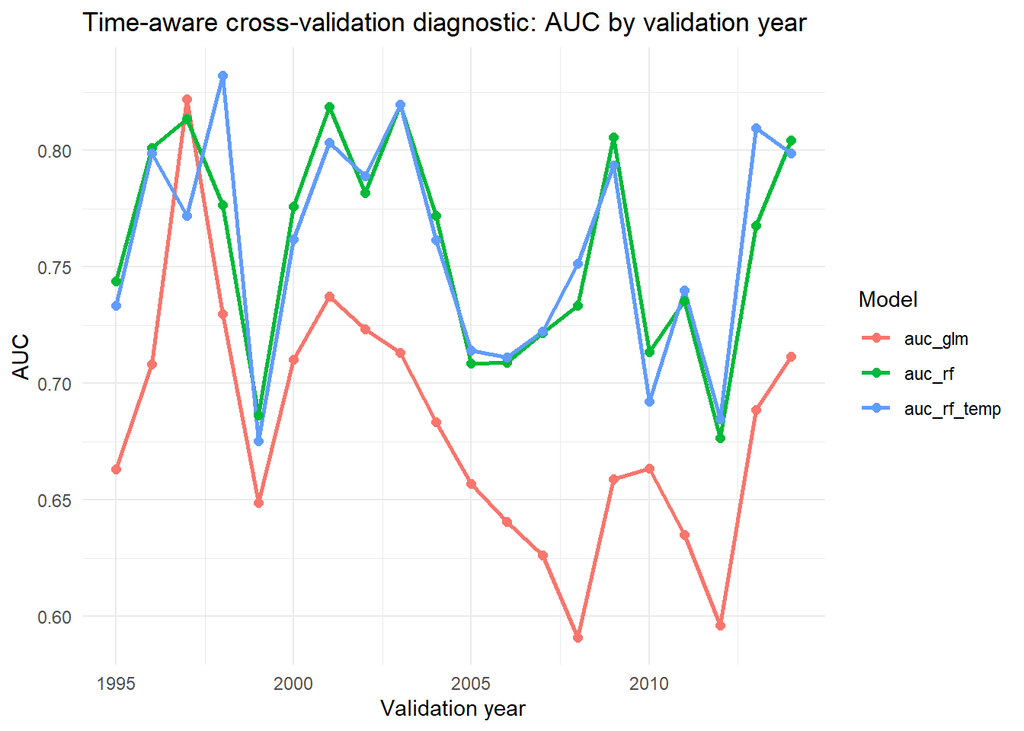

```r
fold_long <- fold_results %>%
  pivot_longer(
    cols = c(auc_glm, auc_rf, auc_rf_temp),
    names_to = "model",
    values_to = "auc"
  )

ggplot(fold_long, aes(x = valid_year, y = auc, color = model)) +
  geom_line(linewidth = 1) +
  geom_point(size = 2) +
  labs(
    title = "Time-aware cross-validation diagnostic: AUC by validation year",
    x = "Validation year",
    y = "AUC",
    color = "Model"
  ) +
  theme_minimal()
```

```r
cat('Overall, Random forest without temperature predictors outperforms logistic regression in AUC by ',
    round(mean(fold_results$auc_rf) / mean(fold_results$auc_glm) * 100, 4) - 100, "% ", sep= '')
```

```
## Overall, Random forest without temperature predictors outperforms logistic regression in AUC by 11.4465%
```

```r
cat('\nOverall, Random forest with temperature predictors outperforms logistic regression in AUC by ',
    round(mean(fold_results$auc_rf_temp) / mean(fold_results$auc_glm) * 100, 4) - 100, "% ", sep= '')
```

```
##
## Overall, Random forest with temperature predictors outperforms logistic regression in AUC by 11.4521%
```

**Comparison**: It is **clear that random forest is a stronger model for predicting wildfires than logistic regression**. However, surprisingly, **incorporating temperatures in the model had extremely little to no improvement for predicting (***11.4465% improvement vs 11.4521%*) . This could be a sign that temperature is relatively correlated to one of the other variables, and that could even mean overfitting even though random forest does relatively well against it. Since there is minuscule improvement between the two random forest model, we will **prefer the random forest model with no temperature predictors over the one with it for simplicity**.

# 5 Summary

We created models that predicts if there will be an occurrence of a notable wildfire in a grid cell of 1 by 1 in latitude and longitude. It **trains using cross-validation that also respects time and doesn’t use future data for prediction**.

The models demonstrated in this report captures a wide variety of predictors including spatial and temporal patterns, fire activity patterns, and even temperature of respective states. Random forest had improved performance over logistic regression; however,**this report found no major improvement in prediction performance between a random forest model accounting for notable wildfires using average monthly temperature + rolling three month average temperature and a random forest without those variables**. This could be a point interest for another report to examine further if it has to do with overfitting or a different selection of temperature variables.